# Storm Analysis Report

Si Hiep Huynh

Saturday, March 21, 2015

## Title

This is report about analyzing storm data. Main purpose of this report is to answer two questions: 1. which types of events (as indicated in the EVTYPE variable) are most harmful with respect to population health? 2. which types of events have the greatest economic consequences?

## Data Processing

### Declare required library

```r
library(data.table)
```

```r
library(ggplot2)
```

### Loading Data

```r
if(!file.exists("StormData.csv.bz2")) {
    download.file(url = "http://d396qusza40orc.cloudfront.net/repdata%2Fdata%2FStormData.csv.bz2", destfile = "StormData.csv.bz2")

}

StormData <- read.csv(bzfile("StormData.csv.bz2"))
```

### Processing Data

We will convert data type to data table to improve performance.

```r
StormData <- data.table(StormData)
```

## Define event type standard

We will initialize a dataframe with [2 x 48] contains event type - storm’s event type, event regular expression for this event type.

```r
eventTypes <- c("Astronomical Low Tide",
                "Avalanche",
                "Blizzard",
                "Coastal Flood",
                "Cold/Wind Chill",
                "Debris Flow",
                "Dense Fog",
                "Dense Smoke",
                "Drought",
                "Dust Devil",
                "Dust Storm",
                "Excessive Heat",
                "Extreme Cold/Wind Chil",
                "Flash Flood",
                "Flood",
                "Frost/Freeze",
                "Funnel Cloud",
                "Freezing Fog",
                "Hail",
                "Heat",
                "Heavy Rain",
                "Heavy Snow",
                "High Surf",
                "High Wind",
                "Hurricane (Typhoon)",
                "Ice Storm",
                "Lake-Effect Snow",
                "Lakeshore Flood",
                "Lightning",
                "Marine Hail",
                "Marine High Wind",
                "Marine Strong Wind",
                "Marine Thunderstorm Wind",
                "Rip Current",
                "Seiche",
                "Sleet",
                "Storm Surge/Tide",
                "Strong Wind",
                "Thunderstorm Wind",
                "Tornado",
                "Tropical Depression",
                "Tropical Storm",
                "Tsunami",
                "Volcanic Ash",
                "Waterspout",
                "Wildfire",
                "Winter Storm",
                "Winter Weather")

eventTypeRegex <- c ("^.*(ABNORMAL|(ASTRONOMICAL.LOW.TIDE)|(BLOW.OUT.TIDE)).*$",
                     "^AVALANC.*$",
                     "^BLIZZARD.*$",
                     "^.*(COASTAL|ASTRONOMICAL.HIGH.TIDE|BEACH).*$",
                     "^(?!.*EXTREME|BITTER|SEVERE)(.*(COLD|WIND)+.*)$",
                     "^.*(Debris.Flow|LANDSLIDE).*$",
                     "^(DENSE.FOG).*$",
                     "^.*(DENSE.SMOKE).*",
                     "^DROUGHT.*$",
                     "DUST.DEVIL|DUST.DEVEL | BLOWING.DUST",
                     "^.*DUST.STORM.*$" ,
                     "^.*(EXCESSIVE.HEAT).*$",
                     "^.*(EXTREME|BITTER|SEVERE|EXCESSIVE).*(COLD|WIND).*$",
                     "^.*(FLASH.*FL[O]+D).*$",
                     "^(FLOOD).*$",
                     "^.*(FREEZE|FROST).*$",
                     "^.*(FUNNEL.CLOUD).*$",
                     "^.*(FREEZING.FOG).*$",
                     "^.*(HAIL).*$",
                     "^.*(HEAT).*$",
                     "^.*(HEAVY.RAIN).*$",
                     "^.*(HEAVY.SNOW).*$",
                     "^.*(HIGH.SURF).*$",
                     "^.*(HIGH.WIND).*$",
                     "^.*(HURRICANE|TYPHOON).*$",
                     "^.*(ICE.STORM).*$",
                     "^.*(LAKE.EFFECT.SNOW).*$",
                     "^.*(LAKESHORE.FLOOD).*$",
                     "^.*(LIGHTING|LIGHTNING).*$",
                     "^.*(MARINE.HAIL).*$",
                     "^.*(MARINE.HIGH.WIND).*$",
                     "^.*(MARINE.STRONG.WIND).*$",
                     "^.*(MARINE.THUNDERSTORM.WIND).*$",
                     "^.*(RIP.CURRENT).*$",
                     "^.*(SEICHE).*$",
                     "^.*(SLEET).*$",
                     "^.*(STORM.SURGE|TIDE).*$",
                     "^.*(STRONG.WIND).*$",
                     "^.*(THUNDERSTORM.WIND).*$",
                     "^.*(TORNADO).*$",
                     "^.*(TROPICAL.DEPRESSION).*$",
                     "^.*(TROPICAL.STORM).*$",
                     "^.*(TSUNAMI).*$",
                     "^.*(VOLCANIC.ASH).*$",
                     "^.*(WATERSPOUT).*$",
                     "^.*(WILDFIRE).*$",
                     "^.*(WINTER.STORM).*$",
                     "^.*(WINTER.WEATHER).*$")

eventdf <- data.frame( eventregx = eventTypeRegex, events = eventTypes, stringsAsFactors = FALSE)
```

### Format events type

From event data frame above, we will find event type of analytic data which match event regular expression. After that, we will update event type name.

```r
StormData$EVTYPE.STD <- "Unknown"


for(i in 1: 48) {
    StormData[grepl(eventdf[i,1],StormData[,8], perl = TRUE), 38] <- eventdf[i,2]
}
```

### Processing damage

We will format damage suffix as: B | b -> 1000.0000.000 M | m -> 1000.000 K | k -> 1000 H | h -> 100 other cases -> 1

```r
StormData$PROPDMGEXP.STD <- 1

StormData$CROPDMGEXP.STD <- 1

StormData <- data.table(StormData)


# Convert PROPDMGEXP
StormData[PROPDMGEXP == "B" | PROPDMGEXP == "b", PROPDMGEXP.STD := 1000000000]
```

[output not shown]

[output cut: 93 more lines]

```r
StormData[PROPDMGEXP == "M" | PROPDMGEXP == "m", PROPDMGEXP.STD := 1000000]
```

[output not shown]

[output cut: 93 more lines]

```r
StormData[PROPDMGEXP == "K" | PROPDMGEXP == "k", PROPDMGEXP.STD := 1000]
```

[output not shown]

[output cut: 93 more lines]

```r
StormData[PROPDMGEXP == "H" | PROPDMGEXP == "h", PROPDMGEXP.STD := 100]
```

[output not shown]

[output cut: 93 more lines]

```r
# Convert CROPEXP
StormData[CROPDMGEXP == "B" | CROPDMGEXP == "b", CROPDMGEXP.STD := 1000000000]
```

[output not shown]

[output cut: 93 more lines]

```r
StormData[CROPDMGEXP == "M" | CROPDMGEXP == "m", CROPDMGEXP.STD := 1000000]
```

[output not shown]

[output cut: 93 more lines]

```r
StormData[CROPDMGEXP == "K" | CROPDMGEXP == "k", CROPDMGEXP.STD := 1000]
```

[output not shown]

[output cut: 93 more lines]

```r
StormData[CROPDMGEXP == "H" | CROPDMGEXP == "h", CROPDMGEXP.STD := 100]
```

[output not shown]

[output cut: 93 more lines]

```r
StormData$TOTAL.INJURIES <- StormData$FATALITIES + StormData$INJURIES

StormData$PROPDMGVAL <- StormData$PROPDMG * StormData$PROPDMGEXP.STD

StormData$CROPDMGVAL <- StormData$CROPDMG * StormData$CROPDMGEXP.STD

StormData$TOTAL.ECONOMIC.DMG.VAL <- StormData$PROPDMGVAL + StormData$CROPDMGVAL
```

## Result

### Q1. Across the United States, which types of events (as indicated in the EVTYPE variable) are most harmful with respect to popuulation health?

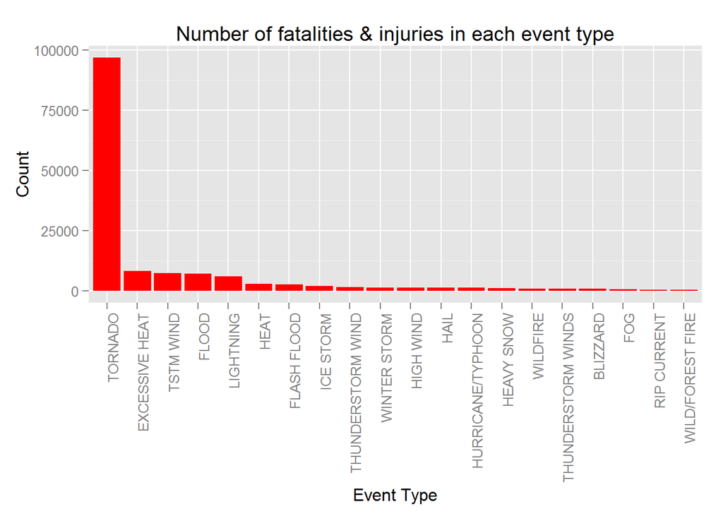

```r
agg <- aggregate(StormData$TOTAL.INJURIES, by = list(StormData$EVTYPE), "sum")
# plot number of fatalities in each event type we plot top 20 events only
agg <- agg[order(-agg$x), ][1:20, ]
agg$Group.1 <- factor(agg$Group.1, levels = agg$Group.1)
g1 <- ggplot(agg, aes(x = Group.1, y = x)) + geom_bar(stat = "identity", fill = "red",
    las = 3) + theme(axis.text.x = element_text(angle = 90, hjust = 1)) + xlab("Event Type") +
    ylab("Count") + ggtitle("Number of fatalities & injuries in each event type")

# plot the results
print(g1)
```

### Q2. Across the United States, which types of events have the greatest economic consequences?

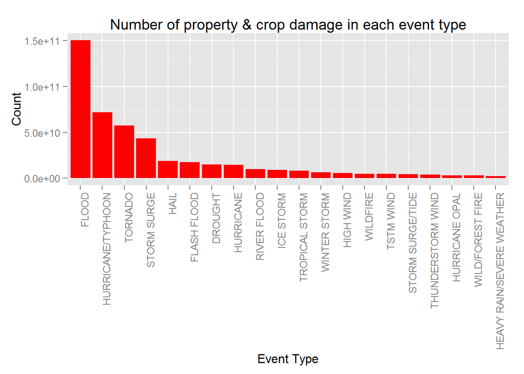

```r
agg <- aggregate(StormData$TOTAL.ECONOMIC.DMG.VAL, by = list(StormData$EVTYPE), "sum")
# plot number of property & crop in each event type we plot top 20 events only
agg <- agg[order(-agg$x), ][1:20, ]
agg$Group.1 <- factor(agg$Group.1, levels = agg$Group.1)
g2 <- ggplot(agg, aes(x = Group.1, y = x)) + geom_bar(stat = "identity", fill = "red",
    las = 3) + theme(axis.text.x = element_text(angle = 90, hjust = 1)) + xlab("Event Type") +
    ylab("Count") + ggtitle("Number of property & crop damage in each event type")

print(g2)
```